# INTAROS - IMR Dataset - RGeostats Workshop Course

D. Renard, F. Ors

January 22th 2019

# Introduction

This paper is meant to demonstrate how to use some scripts to learn on how to use **Geostatistics**. This case study is based on the use of **RGeostats** and scripts developed in the scope of **Intaros** workshop.

The next cells have specific contents that the user must choose to run or to skip. Their order is important.

- Defining the environment for knitr
- Loading the library **Intaros** and cancel any possible projection

```r
library(RIntaros)
projec.toggle(0)
```

- Cleaning the workspace: this paragraph is not systematically performed.

```r
rm(list=ls())
```

## Loading Data

It is based on the **Annual CTD datasets** from Norwegion Institute of Marine Research (IMR). For better efficiency, the dataset has been simplified by:

- reducing the values when the depth lies between 0m and 100m
- regrouping (and averaging) the data by benches of 10m high
- the data set is read from a CSV external file

```r
dir.name   = getwd()
data.name  = "data"
file.name  = "imr_data_by_10m.csv"
db0        = imr_read_csv(file.path(dir.name,data.name,file.name))
```

For the sake of this short demonstration, we focus on a small area (located close to the Norvegian coast)

```r
long_lim   = c(-2,10)
lat_lim    = c(56,62)
image.name = "images"
intaros.save.environ(long_lim = long_lim, lat_lim = lat_lim,
                     flag_file = FALSE,image_name = file.path(dir.name,image.name))
```

# Basic statistics

This paragraph allows the user to check some functions for getting basic statistics, such as:

- defining global information: sampling duration, color setting

```r
years      = subyears = get_db_limits_year(db0)
trimesters = subtrims = seq(1,4)
colyears   = rg.colors(length(years))
cat(build_title("The dataset period is:",time2date(get_db_limits_time(db0))))
```

```
## The dataset period is: (1995-01-07 => 2016-11-29)
```

- check the contents of the data base

```r
db0
```

```
##
## Data Base Characteristics
## =========================
##
## Data Base Summary
## -----------------
## File is organized as a set of isolated points
## Space dimension              = 2
## Number of fields             = 10
## Maximum Number of attributes = 10
## Total number of samples      = 163380
##
## Variables
## ---------
## Field =   1 - Name    =  rank - Locator =  NA
## Field =   2 - Name    =  Longitude - Locator =  x1
## Field =   3 - Name    =  Latitude - Locator =  x2
## Field =   4 - Name    =  Depth - Locator =  NA
## Field =   5 - Name    =  Profil_id - Locator =  NA
## Field =   6 - Name    =  Temperature - Locator =  NA
## Field =   7 - Name    =  Conductivity - Locator =  NA
## Field =   8 - Name    =  Salinity - Locator =  NA
## Field =   9 - Name    =  Time - Locator =  NA
## Field =  10 - Name    =  Vaissel_id - Locator =  NA
```

- getting some basic statistics on the different variables

```r
db.stat.print(db0,funs=c("num","mini","maxi","mean"),
              names=c("Longitude","Latitude","Depth","Temperature","Conductivity","Salinity"))
```

```
##                 Number   Minimum   Maximum      Mean
## Longitude       163380    -2.000    10.000     3.822
## Latitude        163380    56.000    62.000    59.315
## Depth           163380     5.000    95.000    47.921
## Temperature     163380    -0.717    20.556     8.599
## Conductivity    163380    -0.000    45.672    36.126
## Salinity        163380    -0.000    35.640    34.287
```

- display of the data (all data, for all years and all depths)

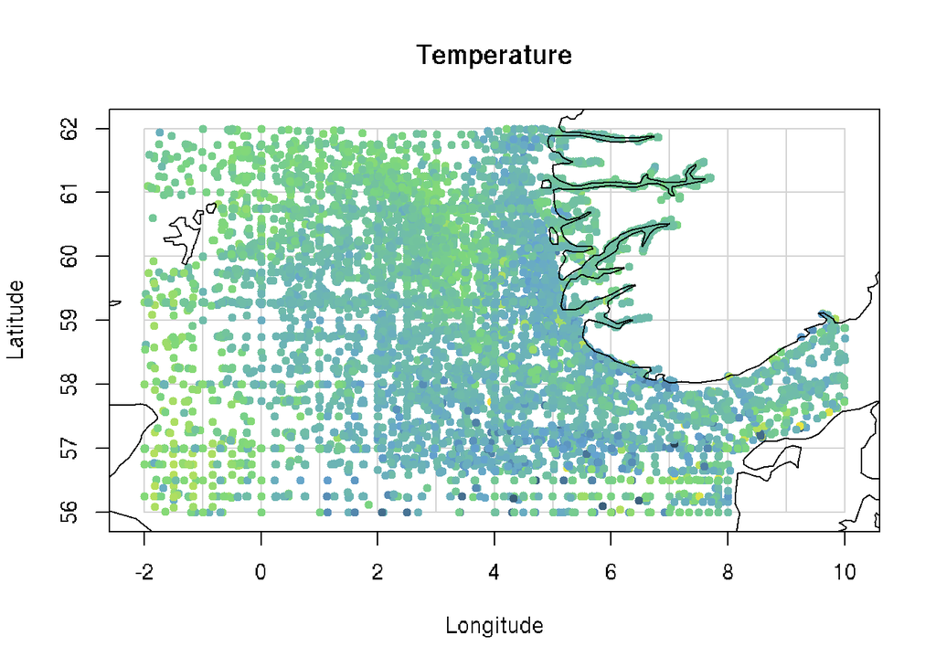

```r
var = "Temperature"
colors.temp = rg.colors(rank=1)
colors.std  = heat.colors(100)
var_scale0 = get_db_limits_var(db0,var)
display_var(db0, var = var, var_scale = var_scale0, colors = colors.temp, title = var,
            filename = var, flag.mesh = TRUE, mesh = 1, flag.coast = TRUE)
```

- histogram of Temperature

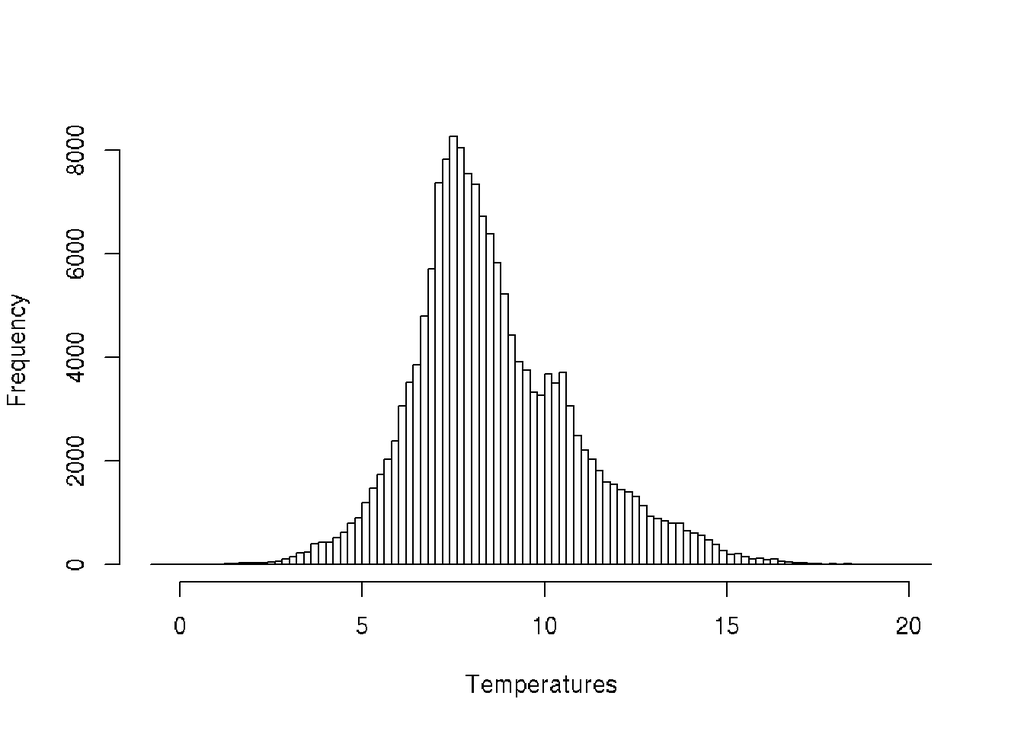

```r
hist(db0[,"Temp*"],breaks=100,xlab="Temperatures",main="")
```

- correlation between variables

```r
rho = correlation(db0,"Temperature","Salinity",title="Salinity vs. Temperature",flag.regr=TRUE)
```

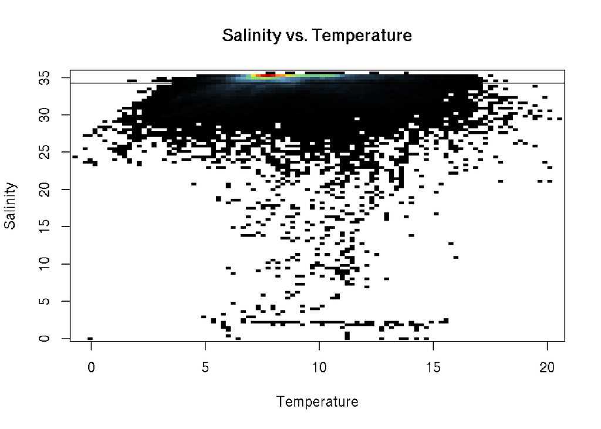

```r
cat("Correlation coefficient=",rho,"\n")
```

```
## Correlation coefficient= 0.005305434
```

- range of depths

```r
db.print(db0,names="Depth",flag.stats=TRUE)
```

```
##
## Data Base Characteristics
## =========================
##
## Data Base Summary
## -----------------
## File is organized as a set of isolated points
## Space dimension              = 2
## Number of fields             = 10
## Maximum Number of attributes = 10
## Total number of samples      = 163380
##
## Data Base Statistics
## --------------------
## 4 - Locator Variable NA (Name=Depth)
##  Nb of data          =     163380
##  Nb of active values =     163380
##  Minimum value       =      5.000
##  Maximum value       =     95.000
##  Mean value          =     47.921
##  Standard Deviation  =     28.072
##  Variance            =    788.051
```

We also learn how to apply some statistics on a sub-sample by performing a **selection**. The argument **var_scale** is defined to set the range of values used for color rendition.

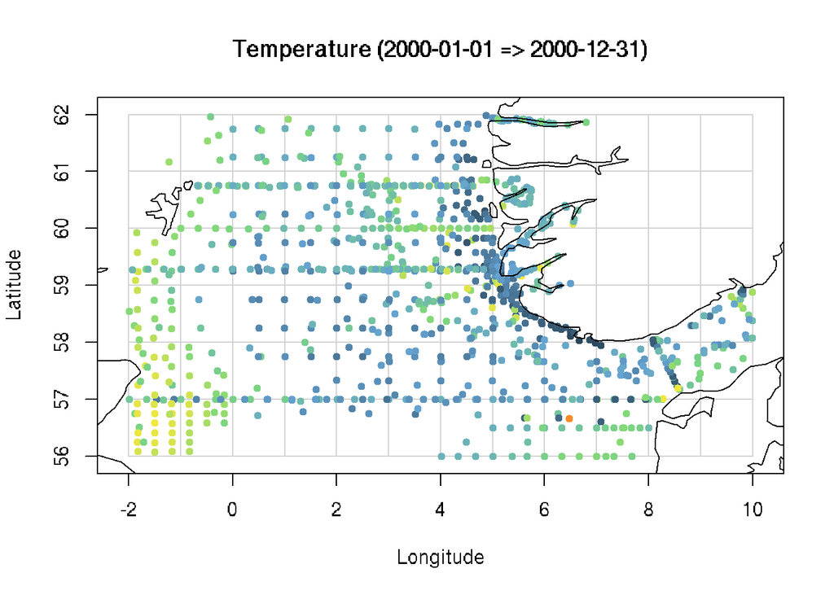

```r
var       = "Temperature"
year      = 2000
date_lim  = create_limits_date(year)
db        = apply_sel(db0, date_lim=date_lim)
var_scale = get_db_limits_var(db,var)
title     = build_title(var, date_lim)
filename  = paste0(var,"_Year_",year)

display_var(db, var, var_scale = var_scale, colors = colors.temp,
            title = title, filename = filename,
            flag.mesh = TRUE, mesh = 1, flag.coast = TRUE)
```

- statistics per block (on the same selection as before)

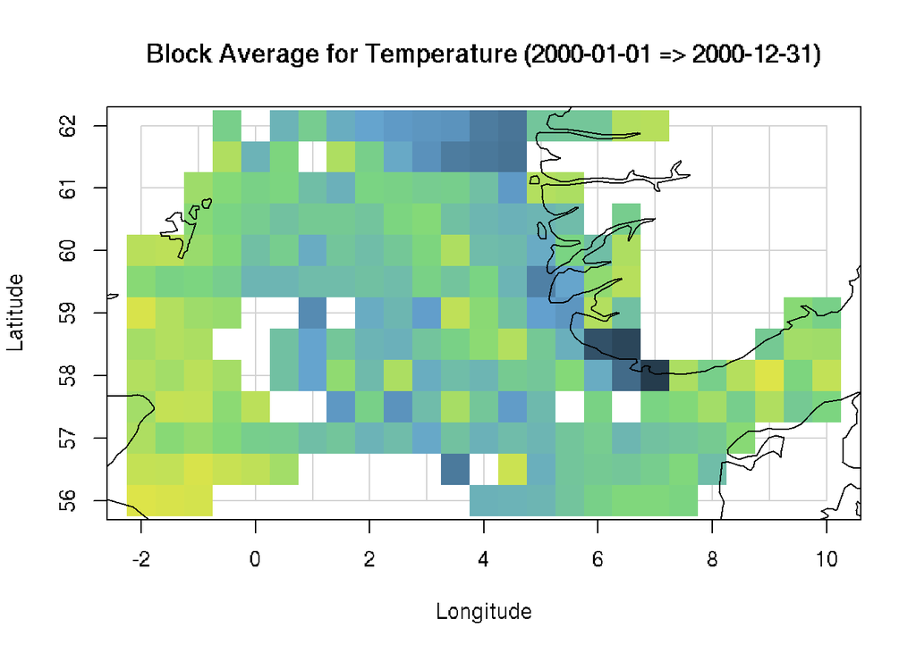

```r
var       = "Temperature"
year      = 2000
date_lim  = create_limits_date(year)
db        = apply_sel(db0, date_lim = date_lim)
var_scale = get_db_limits_var(db,var)
title     = paste("Block Average for", build_title(var, date_lim))
dbg       = stats_grid(db, var, fun = "mean", mesh = 0.5, verbose = FALSE)
filename  = paste0(var,"_Year_",year)

display_stats(dbg, var, var_scale = var_scale, colors = colors.temp,
              title = title, filename = filename,
              flag.mesh = TRUE, mesh = 1, flag.coast = TRUE)
```

- calculating the mean and variance for each year, at 25m depth

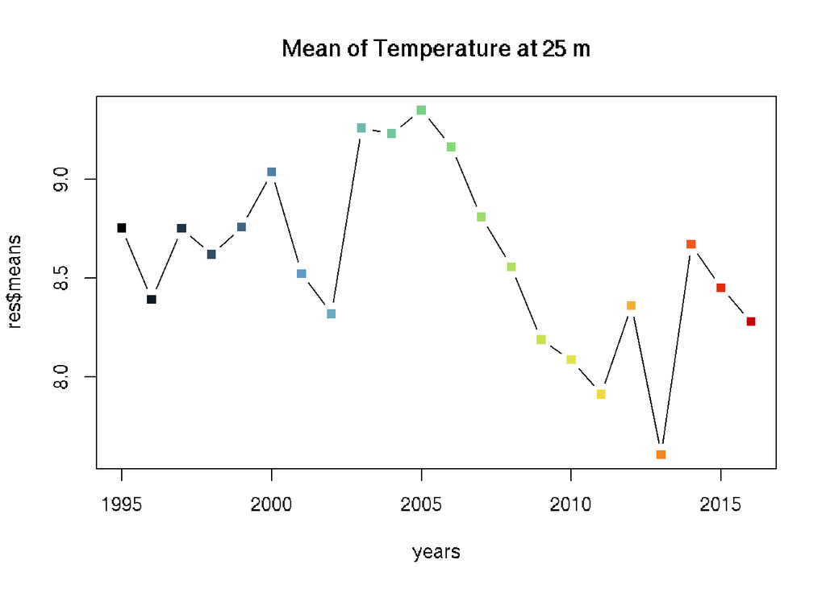

```r
var       = "Temperature"
depth     = 25

# Select the active samples
depth_lim = c(depth,depth)
db        = apply_sel(db0, depth_lim = depth_lim)

# Average Temperature along Time
res       = average_time(db , var, years)

# Display results
plot (years,res$means,type="b",main=paste("Mean of",var,"at",depth,"m"),
      pch=15,lty=1,col=colyears)
```

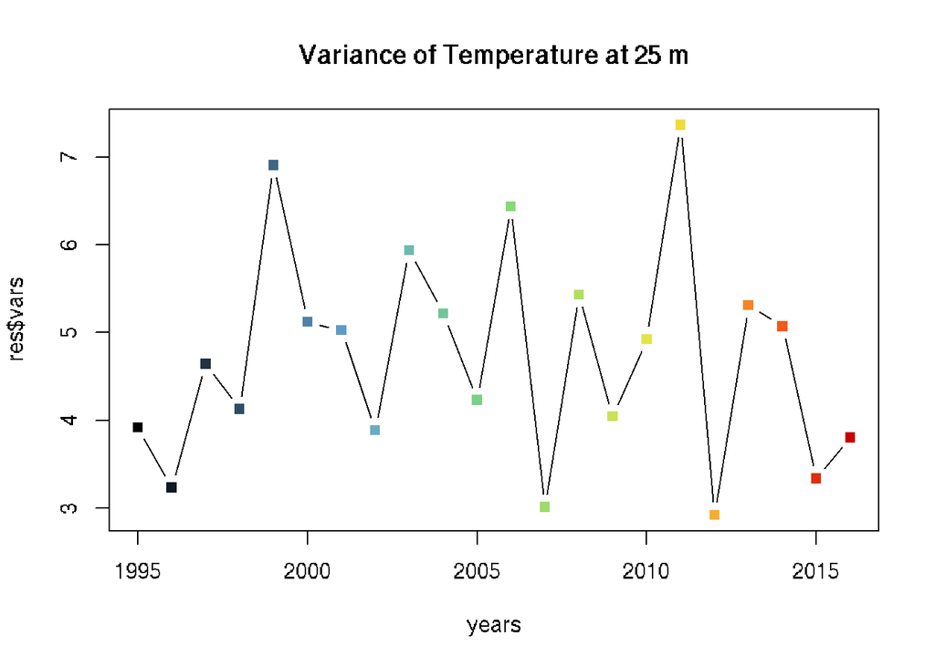

```r
plot (years,res$vars ,type="b",main=paste("Variance of",var,"at",depth,"m"),
      pch=15,lty=1,col=colyears)
```

- calculating the mean and variance (for 2008) for each depth level (every 10m)

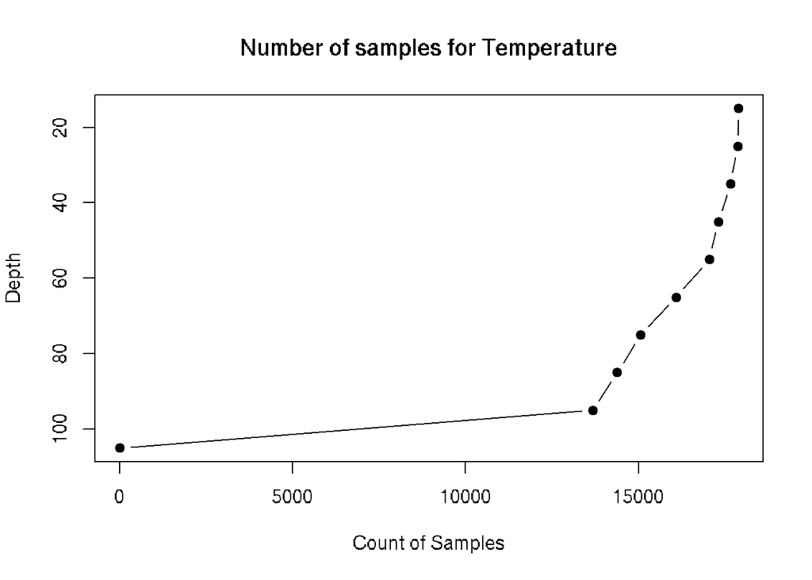

```r
var       = "Temperature"
year      = 2008

# Select the active samples
date_lim  = create_limits_date(year)
db        = apply_sel(db0, date_lim = date_lim)

# Average Temperature along Depth
res       = average_depth(db , var, depth0=0, ddepth=10, ndepth=10)

# Display the results
plot(res$count,res$depths,type="b",main=paste("Number of samples for",var),pch=19,
     xlab="Count of Samples", ylab="Depth", ylim=rev(range(res$depths)))
```

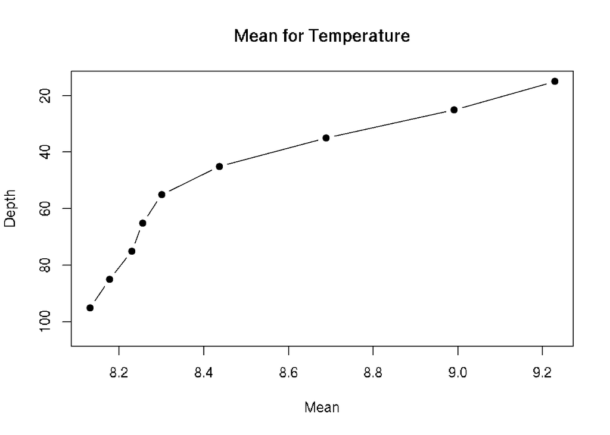

```r
plot(res$means,res$depths,type="b",main=paste("Mean for",var),pch=19,
     xlab="Mean", ylab="Depth", ylim=rev(range(res$depths)))
```

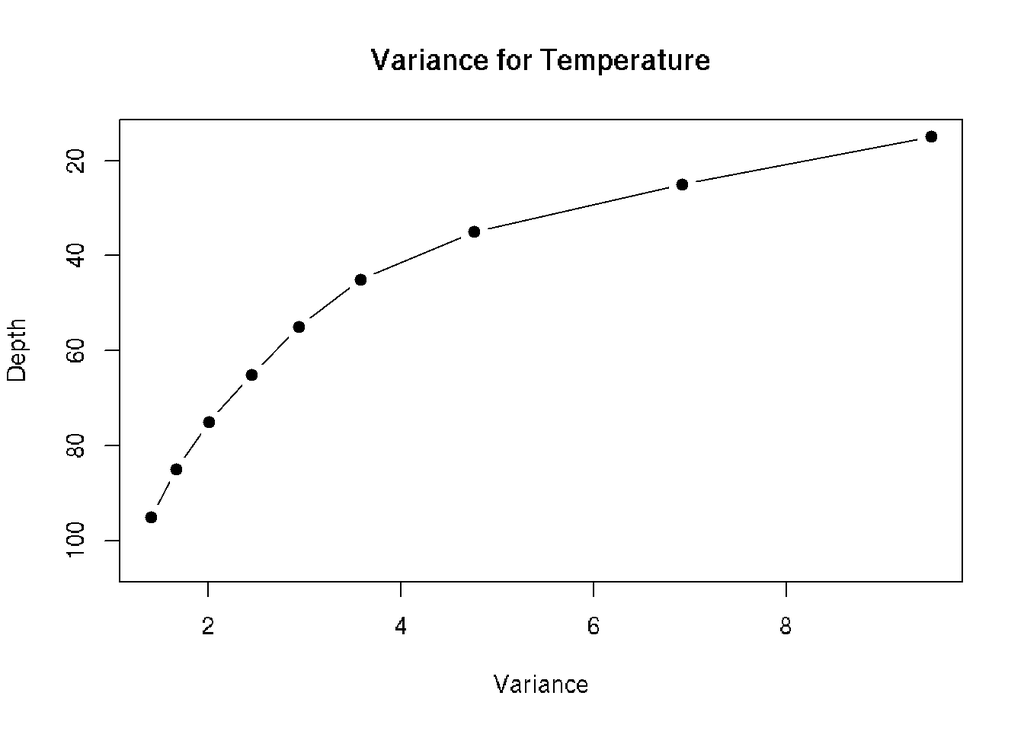

```r
plot(res$vars ,res$depths,type="b",main=paste("Variance for",var),pch=19,
     xlab="Variance", ylab="Depth", ylim=rev(range(res$depths)))
```

# Variography

From this point, all the calculations will be performed based on the values of **temperature** variable, measured in 2008.

Calculate the average omni-directional horizontal variogram(s):

- omni-directional

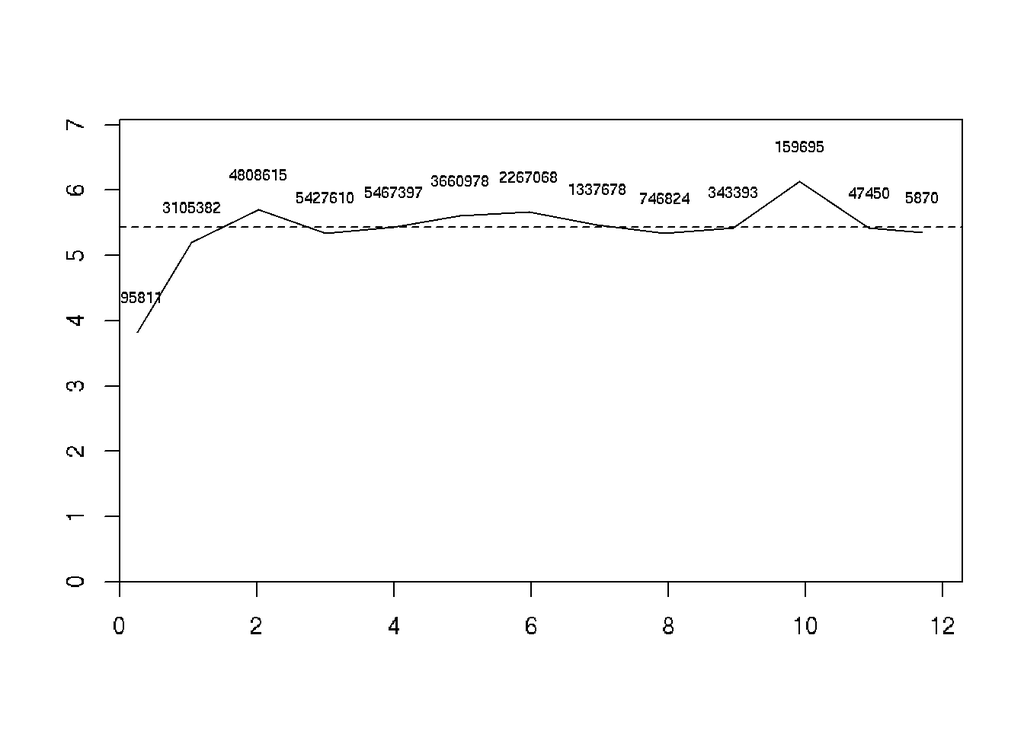

```r
var       = "Temperature"
year      = 2008

# Select the active samples
date_lim  = create_limits_date(year)
db        = apply_sel(db0, date_lim = date_lim)
db        = db.locate(db,var,"z")

# Variogram parameters
vario_lag  = 1
vario_nlag = 20
bench      = 5

# Calculate the Experimental Variogram
vario = prepar_vario(db, dirvect=NA, vario_lag = vario_lag, vario_nlag = vario_nlag,
                     bench = bench, nbench = 0,
                     draw.vario=TRUE, verbose=FALSE, npairpt=TRUE, cex=0.7)
```

- in 4 directions

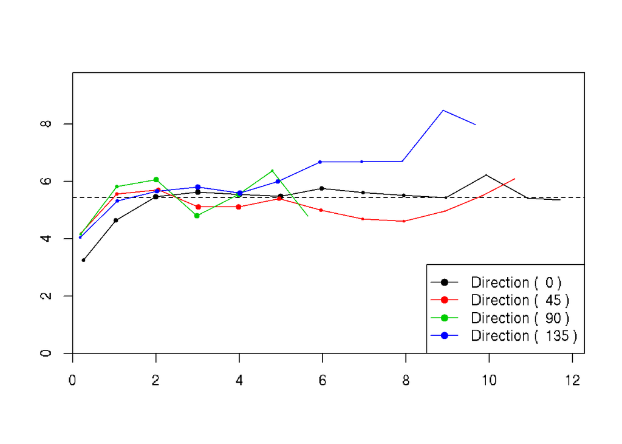

```r
var  = "Temperature"
year = 2008

# Select the active samples
date_lim  = create_limits_date(year)
db        = apply_sel(db0, date_lim = date_lim)
db        = db.locate(db,var,"z")

# Variogram parameters
vario_lag  = 1
vario_nlag = 20
bench      = 5

# Calculate the Experimental Variogram
vario4d = prepar_vario(db, vario_lag = vario_lag, vario_nlag = vario_nlag,
                       dirvect=c(0,45,90,135), bench = bench, nbench = 0,
                       draw.vario=TRUE, verbose=FALSE, npairdw=TRUE, pos.legend=1)
```

We fit the model (using an automatic fitting procedure)

```r
model = model.auto(vario4d, struct = c(1,2,3), verbose=FALSE, pos.legend=1)
```

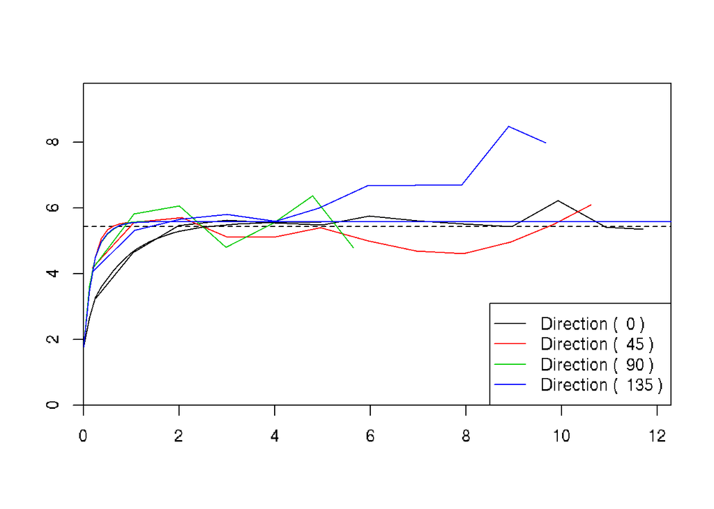

These two steps are regrouped in the method **prepar_model**.

# Cross-validation

We consider the **temperature** variable for year 2008, at 25m depth. This step performs a cross-validation. It includes a calculation of the experimental variogram and the model fitting step. It finally presents a display of the standardized errors (absolute value).

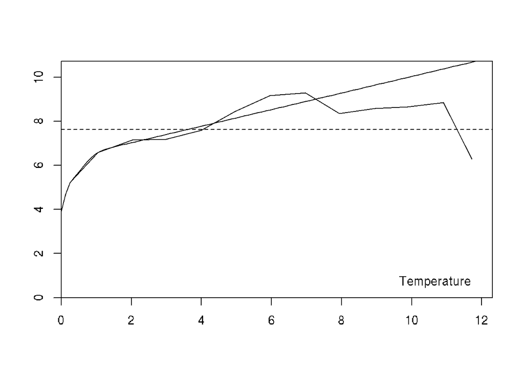

```r
var       = "Temperature"
year      = 2008
depth     = 25

# Select the active samples
depth_lim = c(depth,depth)
date_lim  = create_limits_date(year, trimester=2)
dbc       = apply_sel(db0, depth_lim = depth_lim, date_lim = date_lim, compress=TRUE)

# Variogram parameters
vario_lag  = 1
vario_nlag = 20
bench      = 5

# Perform the Cross-validation
dbp       = xvalid_2D(dbc, var,
                      vario_lag = vario_lag, vario_nlag = vario_nlag, struct = c(1,3,5,12),
                      bench = bench, nbench = 0, dirvect = NA, draw.model=TRUE, radix="Xvalid")
```

```r
# Print the results
db.stat.print(dbp,names="Xvalid*",funs=c("num","mean","var"),title="Cross-Validation Scores")
```

```
##
## Cross-Validation Scores
## -----------------------
##                              Number      Mean  Variance
## Xvalid.Temperature.esterr       280    -0.029     6.281
## Xvalid.Temperature.stderr       280    -0.006     1.133
```

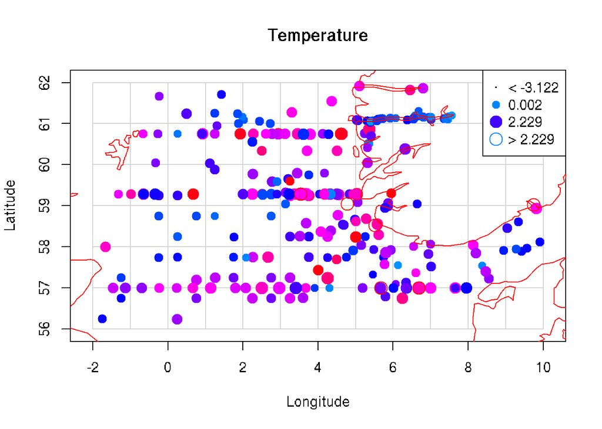

```r
# Plot the results
filename  = paste0("Xvalid_",var,".",year)
display_var(dbp, var = "*stderr", title = var, flag.xvalid = TRUE, colors=rainbow(100),
            filename = filename, pos.legend=7)
```

# Interpolation

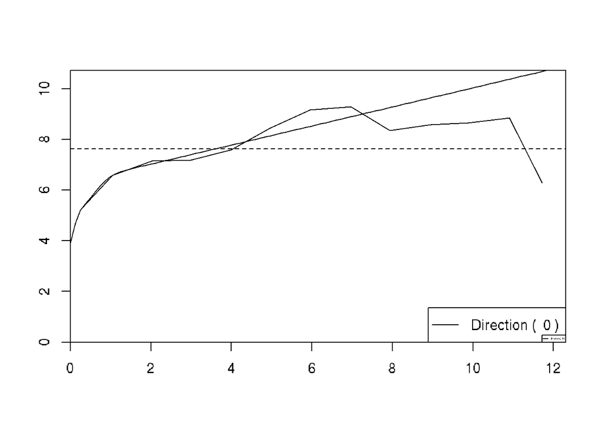

```r
var       = "Temperature"
year      = 2008
depth     = 25

# Select the active samples
depth_lim = c(depth,depth)
date_lim  = create_limits_date(year, trimester=2)
dbc       = apply_sel(db0, depth_lim = depth_lim, date_lim = date_lim, compress=TRUE)

# Variogram parameters
vario_lag  = 1
vario_nlag = 20
bench      = 5

# Perform the Interpolation
dbg = interpolate_2D(dbc, var, mesh = 0.1,
                     vario_lag = vario_lag, vario_nlag = vario_nlag, struct = c(1,3,5,12),
                     bench = bench, nbench = 0, dirvect = NA, draw.model=TRUE, pos.legend=1)
```

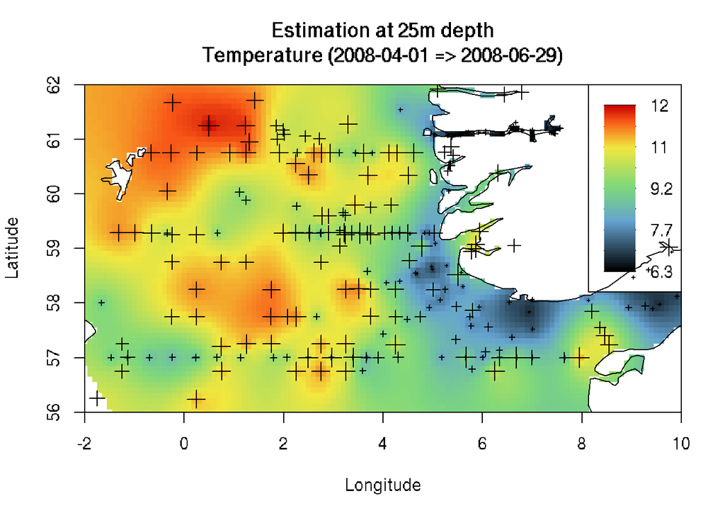

```r
# Display results
filename  = paste0("Estim_",var,".",year)
display_result(dbc, dbg, var = var, depth = depth, flag.estim = TRUE,  colors= colors.temp,
               filename = filename, pos.legend=7)
```

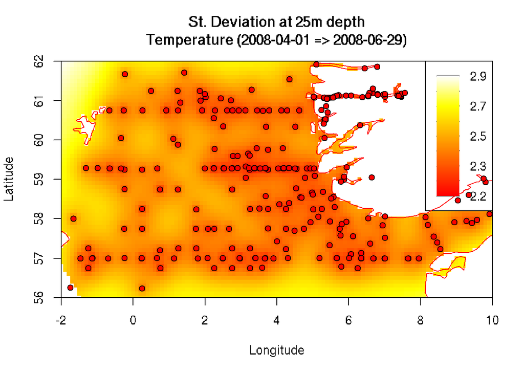

```r
filename  = paste0("Stdev",var,".",year)
display_result(dbc, dbg, var = var, depth = depth, flag.estim = FALSE,
               colors = colors.std, filename = filename, pos.legend=7)
```